# Ryan_Austin_Unit2_Deliverable2_Q3_2

## 3.2 Logistic Regression Model Predicting WNV Presence

```python
# Data and module/library loading
import matplotlib.pyplot as plt
import numpy as np
import pandas as pd
import seaborn as sns

# Important functionality for this lesson
from scipy import stats
import statsmodels.api as sm

# Setting globally figure size in the notebook
plt.rcParams["figure.figsize"] = (8.0, 6.0)

mosquito_data2_df3 = pd.read_csv(r"C:\Users\raust\OneDrive\Documents\0 BrainStation\BrainStation Data Science\Deliverables\Unit 2 Deliverable 2\mosquito_data_part_2.csv")
```

#### With a logistic regression model, the variable to be predicted is categorical.

#### As with the linear regression model, all independent variables will have to be made numeric.

```python
# To prepare logistic regression model to predict WNV presence, identify the categorical variables
mosquito_data2_df3.info()

# The relevant independent variables will be Address Block, Trap, Trap type, Date, and Species.
```

```
<class 'pandas.core.frame.DataFrame'>
RangeIndex: 18495 entries, 0 to 18494
Data columns (total 12 columns):
 #   Column           Non-Null Count  Dtype
---  ------           --------------  -----
 0   Year             18495 non-null  int64
 1   Week             18495 non-null  int64
 2   Address Block    18495 non-null  object
 3   Trap             18495 non-null  object
 4   Trap type        18495 non-null  object
 5   Date             18495 non-null  object
 6   Mosquito number  18495 non-null  int64
 7   WNV Present      18495 non-null  object
 8   Species          18495 non-null  object
 9   Lat              18495 non-null  float64
 10  Lon              18495 non-null  float64
 11  Month            18495 non-null  int64
dtypes: float64(2), int64(4), object(6)
memory usage: 1.7+ MB
```

## Preliminary Assessment: Notes Based on Subject Matter Expertise

##### Year: Unless the mosquitos have an n-year cycle, it is not clear how "Year" could be used as a *predictive* measure for WNV Present.

##### Week: Mosquito prevalence is seasonal because year by year the weeks of the year are consistent with respect to the climatic conditions favourable to mosquito breeding. Still, "Week" is too granular and would add too much complexity and unnecessary computation for the model. "Month" would be a better proxy for mosquito prevalance time frame.

##### Address Block: A categorical variable that will have to be converted to a numeric variable. Still, the only alternatives are that mosquitos were found at the address or they were not. A given address block would be more useful for a heat map showing gradient than for a regression model predicting WNV presence.

##### Trap: Like "Address Block", "Trap ID" is a categorical variable that is more useful for a heat map than a regression model predicting mosquito count.There are too many trap IDs to include in a practical model.

##### Trap Type: A given trap type may have captured more mosquitos, giving some insight into which trap to use more often, but trap type is **not** a logical predictor of WNV presence.

##### Date: Even more than "Week", the date timestamp down to the second is too granular and computationally intensive for a regression model. Month is the more practical predictor.

##### Mosquito number: The count of mosquitos is a sensible indicator of the likelihood of detecting West Nile Virus.

##### Species: Species is important to know if any harbour the virus more than others.

##### Lat: Without being paired with longitude *as a coordinate* , latitude is not really a credible predictor. However, since it is known that the test area is limited to the Chicago area, knowing latitude should be one of the better predictors of WNV presence.

##### Lon: Longitude is one of the better predictors of WNV presence for the same reasons as latitude, and shares the same limitation.

##### Month: The most practical predictor of when a virus carried by a seasonal species is most present.

```python
# Prepare to convert categorical (i.e. object) fields to numerical ones.

mosquito_data2_df3b = mosquito_data2_df3.copy()

from sklearn.preprocessing import OneHotEncoder

# Preliminary review of the data types, with attention to Object data types.
mosquito_data2_df3b.info()
```

```
<class 'pandas.core.frame.DataFrame'>
RangeIndex: 18495 entries, 0 to 18494
Data columns (total 12 columns):
 #   Column           Non-Null Count  Dtype
---  ------           --------------  -----
 0   Year             18495 non-null  int64
 1   Week             18495 non-null  int64
 2   Address Block    18495 non-null  object
 3   Trap             18495 non-null  object
 4   Trap type        18495 non-null  object
 5   Date             18495 non-null  object
 6   Mosquito number  18495 non-null  int64
 7   WNV Present      18495 non-null  object
 8   Species          18495 non-null  object
 9   Lat              18495 non-null  float64
 10  Lon              18495 non-null  float64
 11  Month            18495 non-null  int64
dtypes: float64(2), int64(4), object(6)
memory usage: 1.7+ MB
```

```python
categories_to_make_numerical = mosquito_data2_df3b.select_dtypes(include='object').columns.tolist()

mosquito_data2_ddf3 = pd.get_dummies(mosquito_data2_df3b, columns=categories_to_make_numerical, drop_first=True)

mosquito_data2_ddf3.head()
```

|  | Year | Week | Mosquito number | Lat | Lon | Month | Address Block_100XX W OHARE AIRPORT | Address Block_101XX S STONY ISLAND AVE | Address Block_104XX S OGLESBY AVE | Address Block_104XX S VINCENNES AVE | ... | Date_2019-08-22 00:08:00 | Date_2019-08-29 00:08:00 | Date_2019-09-05 00:09:00 | Date_2019-09-12 00:09:00 | Date_2019-09-19 00:09:00 | Date_2019-09-26 00:09:00 | WNV Present_positive | Species_CULEX RESTUANS | Species_CULEX SALINARIUS | Species_CULEX TERRITANS |
| --- | --- | --- | --- | --- | --- | --- | --- | --- | --- | --- | --- | --- | --- | --- | --- | --- | --- | --- | --- | --- | --- |
| 0 | 2019 | 39 | 2 | 41.977738 | -87.880969 | 9 | True | False | False | False | ... | False | False | False | False | False | True | False | True | False | False |
| 1 | 2019 | 39 | 1 | 41.798211 | -87.736925 | 9 | False | False | False | False | ... | False | False | False | False | False | True | False | True | False | False |
| 2 | 2019 | 39 | 2 | 41.987245 | -87.689417 | 9 | False | False | False | False | ... | False | False | False | False | False | True | False | True | False | False |
| 3 | 2019 | 39 | 1 | 41.953664 | -87.724987 | 9 | False | False | False | False | ... | False | False | False | False | False | True | False | True | False | False |
| 4 | 2019 | 39 | 9 | 41.657069 | -87.546049 | 9 | False | False | False | False | ... | False | False | False | False | False | True | False | True | False | False |

5 rows × 652 columns

```python
# Data type verification to ensure no Object type data types remain.
mosquito_data2_ddf3.info()
```

```
<class 'pandas.core.frame.DataFrame'>
RangeIndex: 18495 entries, 0 to 18494
Columns: 652 entries, Year to Species_CULEX TERRITANS
dtypes: bool(646), float64(2), int64(4)
memory usage: 12.2 MB
```

```python
# Prepare independent variables
# remove Mosquito number and WNV Present
mosquito_data2_ddf3_X = mosquito_data2_ddf3.drop(['WNV Present_positive'], axis=1)
mosquito_data2_ddf3_X.info()

# Add a constant for the intercept
mosquito_data2_ddf3_X_wconst = sm.add_constant(mosquito_data2_ddf3_X)
mosquito_data2_ddf3_X_wconst.info()
```

```
<class 'pandas.core.frame.DataFrame'>
RangeIndex: 18495 entries, 0 to 18494
Columns: 651 entries, Year to Species_CULEX TERRITANS
dtypes: bool(645), float64(2), int64(4)
memory usage: 12.2 MB
<class 'pandas.core.frame.DataFrame'>
RangeIndex: 18495 entries, 0 to 18494
Columns: 652 entries, const to Species_CULEX TERRITANS
dtypes: bool(645), float64(3), int64(4)
memory usage: 12.4 MB
```

```python
# Prepare dependent variable
mosquito_data2_df3b_y = mosquito_data2_df3b['WNV Present']
mosquito_data2_df3b_y.head()
```

```
0    negative
1    negative
2    negative
3    negative
4    negative
Name: WNV Present, dtype: object
```

## Model Refinement

##### While regression models should predict the target as much as possible, they should also be economical. If the same phenomena can be predicted with fewer variables, then it would be more resource-effective to remove the redundant variables.

#### Variable redundancy can be inferred from high collinearity between independent variables of a model. Thus, an important step in model building is to examine the data for multicollinearity via a correlation matrix.

```python
# Check for multicollinearity
mosquito_data2_ddf3_X.corr()
```

|  | Year | Week | Mosquito number | Lat | Lon | Month | Address Block_100XX W OHARE AIRPORT | Address Block_101XX S STONY ISLAND AVE | Address Block_104XX S OGLESBY AVE | Address Block_104XX S VINCENNES AVE | ... | Date_2019-08-15 00:08:00 | Date_2019-08-22 00:08:00 | Date_2019-08-29 00:08:00 | Date_2019-09-05 00:09:00 | Date_2019-09-12 00:09:00 | Date_2019-09-19 00:09:00 | Date_2019-09-26 00:09:00 | Species_CULEX RESTUANS | Species_CULEX SALINARIUS | Species_CULEX TERRITANS |
| --- | --- | --- | --- | --- | --- | --- | --- | --- | --- | --- | --- | --- | --- | --- | --- | --- | --- | --- | --- | --- | --- |
| Year | 1.000000 | -0.023283 | 0.129326 | 0.093983 | -0.094628 | -0.100847 | 0.105230 | 0.020316 | -0.009682 | -0.018213 | ... | 0.120601 | 0.106448 | 0.100820 | 0.077099 | 0.092532 | 0.081676 | 0.078036 | 0.343895 | -0.066536 | 0.005373 |
| Week | -0.023283 | 1.000000 | -0.033900 | -0.002876 | 0.002967 | 0.948940 | -0.018139 | 0.018524 | 0.001691 | -0.031698 | ... | 0.033973 | 0.045009 | 0.056858 | 0.054361 | 0.078302 | 0.080642 | 0.088061 | -0.315605 | -0.011918 | 0.036645 |
| Mosquito number | 0.129326 | -0.033900 | 1.000000 | 0.096820 | -0.151421 | -0.040426 | 0.141671 | 0.117719 | -0.004846 | -0.039560 | ... | -0.008809 | -0.022020 | -0.030556 | -0.023298 | -0.019135 | -0.026865 | -0.029838 | 0.070999 | -0.072859 | -0.150962 |
| Lat | 0.093983 | -0.002876 | 0.096820 | 1.000000 | -0.749416 | -0.011544 | 0.381654 | -0.175549 | -0.009339 | -0.111377 | ... | 0.008778 | 0.002295 | 0.000279 | -0.007437 | 0.002635 | -0.000752 | -0.006163 | 0.076660 | -0.004388 | -0.056925 |
| Lon | -0.094628 | 0.002967 | -0.151421 | -0.749416 | 1.000000 | 0.010695 | -0.621158 | 0.191513 | 0.011313 | 0.050463 | ... | -0.004174 | 0.000858 | -0.001143 | 0.005224 | 0.007103 | 0.005875 | 0.010427 | -0.055278 | -0.004243 | 0.078145 |
| ... | ... | ... | ... | ... | ... | ... | ... | ... | ... | ... | ... | ... | ... | ... | ... | ... | ... | ... | ... | ... | ... |
| Date_2019-09-19 00:09:00 | 0.081676 | 0.080642 | -0.026865 | -0.000752 | 0.005875 | 0.068688 | -0.007179 | 0.000638 | -0.000367 | -0.004329 | ... | -0.003682 | -0.003250 | -0.003078 | -0.002354 | -0.002825 | 1.000000 | -0.002382 | 0.012422 | 0.004327 | 0.013598 |
| Date_2019-09-26 00:09:00 | 0.078036 | 0.088061 | -0.029838 | -0.006163 | 0.010427 | 0.065627 | -0.013167 | 0.001316 | -0.000351 | -0.004136 | ... | -0.003518 | -0.003105 | -0.002941 | -0.002249 | -0.002699 | -0.002382 | 1.000000 | 0.011971 | 0.005033 | 0.030965 |
| Species_CULEX RESTUANS | 0.343895 | -0.315605 | 0.070999 | 0.076660 | -0.055278 | -0.327509 | 0.034856 | -0.002211 | 0.005496 | 0.012397 | ... | 0.032046 | 0.041682 | 0.031380 | 0.018449 | 0.032285 | 0.012422 | 0.011971 | 1.000000 | -0.148808 | -0.305582 |
| Species_CULEX SALINARIUS | -0.066536 | -0.011918 | -0.072859 | -0.004388 | -0.004243 | -0.010218 | 0.029988 | -0.001791 | -0.000818 | -0.003925 | ... | -0.008201 | 0.000356 | -0.006856 | 0.005222 | -0.006292 | 0.004327 | 0.005033 | -0.148808 | 1.000000 | -0.025404 |
| Species_CULEX TERRITANS | 0.005373 | 0.036645 | -0.150962 | -0.056925 | 0.078145 | 0.032683 | -0.053359 | -0.007651 | -0.001680 | -0.014015 | ... | 0.030711 | -0.003334 | 0.010260 | 0.015714 | 0.000330 | 0.013598 | 0.030965 | -0.305582 | -0.025404 | 1.000000 |

651 rows × 651 columns

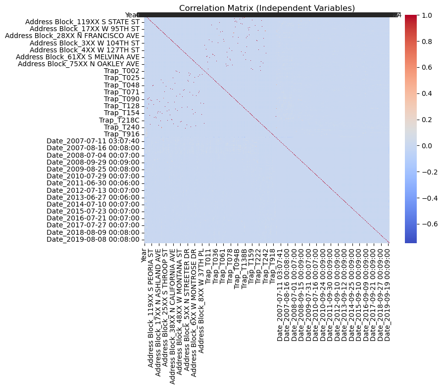

```python
# Testing for multicollinearity among the independent variables.
corr_mat = mosquito_data2_ddf3_X.corr()

# Heatmap for visualization
sns.heatmap(corr_mat, annot=True, cmap='coolwarm')
plt.title('Correlation Matrix (Independent Variables)')
plt.show()
```

## Impressions of Sub-Sample 1

##### The 'Date' feature carries data that is too granular. A previous analysis found 'Month' to be a better proxy for time of incidence.

##### The 'Trap' feature is too granular, and is where most of the multicollinearity occurs. 'Trap type' should suffice.

##### The 'Address Block' feature is very granular. However, it provides better location data than latitude and longitude, which need to be considered together as a coordinate to be informative.

##### I will reload the data for clarity of step progression.

## The Perspective of Subject Matter Expertise

##### An epidemiological study of WNV presence should focus on patterns in location, date-time, and species.

##### Location is important because infectious disease is spread by contact at identifiable locations. To capture location, there is data related to latitude, longitude, and address block. Trap (Trap ID) may be a proxy for location if the coordinates of the individual units are readily known. I argue that Address Block can serve as the sole proxy for location.

##### For the date-time factor, there are a number of features: Year, Month, Week, and Date (timestamp). WNV is being spread by mosquitos, whose appearance is seasonal (i.e. summer months). While some years may have higher incidence than others, using Year in the model is of questionable value for predictive purposes, unless some relationship can be made between multiyear cycles (e.g. prime number years). That is not the case with WNV. Weeks may be informative, but intuitively, the weeks of interest should correlate highly with the months of interest. Weeks is too granular to be practical in the model. Date, capturing the precise time stamp down to the second, is even more granular and so less practical for a regression model. Date-Time could/should arguably be captured by "Month" alone.

##### Species is important because some species may harbour the virus more than others.

```python
# Reload the data then remove the 'Date', 'Trap', 'Lat', 'Lon' features before recreating the dummy variables.

# Data and module/library loading
import matplotlib.pyplot as plt
import numpy as np
import pandas as pd
import seaborn as sns

# Important functionality for this lesson
from scipy import stats
import statsmodels.api as sm

# Setting globally figure size in the notebook
plt.rcParams["figure.figsize"] = (8.0, 6.0)

mosquito_data2_df3 = pd.read_csv(r"C:\Users\raust\OneDrive\Documents\0 BrainStation\BrainStation Data Science\Deliverables\Unit 2 Deliverable 2\mosquito_data_part_2.csv")

# Prepare to convert categorical (i.e. object) fields to numerical ones.
mosquito_data2_df3b = mosquito_data2_df3.copy()

# Drop the problematic columns
mosquito_data2_df3c = mosquito_data2_df3b.drop(['Year', 'Week', 'Date', 'Trap', 'Lat', 'Lon'], axis=1)

from sklearn.preprocessing import OneHotEncoder

categories_to_make_numerical = mosquito_data2_df3c.select_dtypes(include='object').columns.tolist()

mosquito_data2_ddf3 = pd.get_dummies(mosquito_data2_df3c, columns=categories_to_make_numerical, drop_first=True)


mosquito_data2_ddf3.head() # Check
```

|  | Mosquito number | Month | Address Block_100XX W OHARE AIRPORT | Address Block_101XX S STONY ISLAND AVE | Address Block_104XX S OGLESBY AVE | Address Block_104XX S VINCENNES AVE | Address Block_105XX S CALIFORNIA AVE | Address Block_109XX S COTTAGE GROVE AVE | Address Block_10XX E 67TH ST | Address Block_10XX W 95TH ST | ... | Address Block_96XX S LONGWOOD DR | Address Block_98XX S AVENUE G | Address Block_9XX W GARFIELD BLVD | Trap type_GRAVID | Trap type_OVI | Trap type_SENTINEL | WNV Present_positive | Species_CULEX RESTUANS | Species_CULEX SALINARIUS | Species_CULEX TERRITANS |
| --- | --- | --- | --- | --- | --- | --- | --- | --- | --- | --- | --- | --- | --- | --- | --- | --- | --- | --- | --- | --- | --- |
| 0 | 2 | 9 | True | False | False | False | False | False | False | False | ... | False | False | False | True | False | False | False | True | False | False |
| 1 | 1 | 9 | False | False | False | False | False | False | False | False | ... | False | False | False | True | False | False | False | True | False | False |
| 2 | 2 | 9 | False | False | False | False | False | False | False | False | ... | False | False | False | True | False | False | False | True | False | False |
| 3 | 1 | 9 | False | False | False | False | False | False | False | False | ... | False | False | False | True | False | False | False | True | False | False |
| 4 | 9 | 9 | False | False | False | False | False | False | False | False | ... | False | False | False | True | False | False | False | True | False | False |

5 rows × 162 columns

```python
# Prepare independent variables
# remove WNV Present
mosquito_data2_ddf3_X = mosquito_data2_ddf3.drop(['WNV Present_positive'], axis=1)
mosquito_data2_ddf3_X.info()

# Add a constant for the intercept
mosquito_data2_ddf3_X_wconst = sm.add_constant(mosquito_data2_ddf3_X)
mosquito_data2_ddf3_X_wconst.info()
```

```
<class 'pandas.core.frame.DataFrame'>
RangeIndex: 18495 entries, 0 to 18494
Columns: 161 entries, Mosquito number to Species_CULEX TERRITANS
dtypes: bool(159), int64(2)
memory usage: 3.1 MB
<class 'pandas.core.frame.DataFrame'>
RangeIndex: 18495 entries, 0 to 18494
Columns: 162 entries, const to Species_CULEX TERRITANS
dtypes: bool(159), float64(1), int64(2)
memory usage: 3.2 MB
```

[figure not shown]

```python
# Testing for multicollinearity among the independent variables.
corr_mat = mosquito_data2_ddf3_X.corr()

# Heatmap for visualization
sns.heatmap(corr_mat, annot=True, cmap='coolwarm')
plt.title('Correlation Matrix (Independent Variables)')
plt.show()
```

## Impressions of Sub-Sample 2

#### The above result is not satisfactory either, as there are too many address blocks for the model to be practical.

#### Next, I will try to determine the address blocks with the highest correlation to the target variable, and only keep those.

#### I will again re-import and prepare the data for clarity of steps.

```python
# Data and module/library loading
import matplotlib.pyplot as plt
import numpy as np
import pandas as pd
import seaborn as sns

# Important functionality for this lesson
from scipy import stats
import statsmodels.api as sm

# Setting globally figure size in the notebook
plt.rcParams["figure.figsize"] = (8.0, 6.0)

mosquito_data2_df3 = pd.read_csv(r"C:\Users\raust\OneDrive\Documents\0 BrainStation\BrainStation Data Science\Deliverables\Unit 2 Deliverable 2\mosquito_data_part_2.csv")

# Prepare to convert categorical (i.e. object) fields to numerical ones.
mosquito_data2_df3b = mosquito_data2_df3.copy()

# Convert Address Block and WNV Present to dummy variables to see which blocks correlate highly with WNV Present
address_WNVpresent_df = pd.DataFrame(mosquito_data2_df3b, columns=['Address Block', 'WNV Present'])
#address_WNVpresent_df.head()

address_WNVpresent_ddf = pd.get_dummies(address_WNVpresent_df)
address_WNVpresent_ddf.head()

# Find correlations between Address Block and WNV Present
top_corr_addr_WNVneg = address_WNVpresent_ddf.corr()["WNV Present_negative"].nlargest(20)
print(top_corr_addr_WNVneg)
print("")
top_corr_addr_WNVpos = address_WNVpresent_ddf.corr()["WNV Present_positive"].nlargest(20)
print(top_corr_addr_WNVpos)
```

```
WNV Present_negative                       1.000000
Address Block_71XX S SOUTH SHORE DR        0.047296
Address Block_37XX E 118TH ST              0.043216
Address Block_131XX S BRANDON AVE          0.040598
Address Block_12XX W GREENLEAF AVE         0.036494
Address Block_131XX S TORRENCE AVE         0.036273
Address Block_11XX W ROOSEVELT RD          0.035523
Address Block_35XX W 116TH ST              0.032717
Address Block_109XX S COTTAGE GROVE AVE    0.031245
Address Block_75XX N OAKLEY AVE            0.030926
Address Block_22XX N CANNON DR             0.030665
Address Block_11XX S CALIFORNIA AVE        0.030612
Address Block_81XX S ASHLAND               0.029780
Address Block_10XX E 67TH ST               0.029667
Address Block_9XX W GARFIELD BLVD          0.028518
Address Block_79XX S CHICAGO               0.025176
Address Block_35XX W 51ST ST               0.023696
Address Block_24XX E 105TH ST              0.023673
Address Block_89XX S MUSKEGON AVE          0.023143
Address Block_37XX N KEDVALE AVE           0.022558
Name: WNV Present_negative, dtype: float64

WNV Present_positive                      1.000000
Address Block_100XX W OHARE AIRPORT       0.116918
Address Block_41XX N OAK PARK AVE         0.054475
Address Block_70XX N MOSELLE AVE          0.045535
Address Block_71XX N HARLEM AVE           0.038349
Address Block_39XX N SPRINGFIELD AVE      0.030689
Address Block_101XX S STONY ISLAND AVE    0.030366
Address Block_36XX N PITTSBURGH AVE       0.030135
Address Block_58XX N PULASKI RD           0.029331
Address Block_67XX S KEDZIE AVE           0.026332
Address Block_42XX W 65TH ST              0.026118
Address Block_52XX S KOLMAR AVE           0.025720
Address Block_58XX N WESTERN AVE          0.023721
Address Block_91XX W HIGGINS RD           0.023618
Address Block_1XX N CENTRAL PARK DR       0.023309
Address Block_82XX S KOSTNER AVE          0.021987
Address Block_70XX W ARMITAGE AVE         0.020254
Address Block_64XX W STRONG ST            0.020120
Address Block_60XX N AVONDALE AVE         0.020010
Address Block_22XX W 113TH ST             0.019576
Name: WNV Present_positive, dtype: float64
```

#### No address block appeared among the top 20 for both positive and negative WNV presence.

#### Ohare Airport had double the correlation (and a positive presence correlation) of any other address block. The address block for Ohare Airport will be used as the proxy for "location feature". Including any others would increase the complexity of the model, with questionable benefit.

#### A scatterplot mapping WNV presence by latitude and longitude would be informative. It may roughly show the geographic shape of the Chicagoland test area.

```python
# Prepare independent variables
# remove WNV Present
mosquito_data2_ddf3_X = pd.DataFrame(mosquito_data2_ddf3, columns=['Mosquito number', 'Month', 'Address Block_100XX W OHARE AIRPORT', 'Trap type_GRAVID', 'Trap type_OVI', 'Trap type_SENTINEL', 'Species_CULEX RESTUANS', 'Species_CULEX SALINARIUS', 'Species_CULEX TERRITANS'])
mosquito_data2_ddf3_X.info()

# Add a constant for the intercept
mosquito_data2_ddf3_X_wconst = sm.add_constant(mosquito_data2_ddf3_X)
mosquito_data2_ddf3_X_wconst.info()
```

```
<class 'pandas.core.frame.DataFrame'>
RangeIndex: 18495 entries, 0 to 18494
Data columns (total 9 columns):
 #   Column                               Non-Null Count  Dtype
---  ------                               --------------  -----
 0   Mosquito number                      18495 non-null  int64
 1   Month                                18495 non-null  int64
 2   Address Block_100XX W OHARE AIRPORT  18495 non-null  bool
 3   Trap type_GRAVID                     18495 non-null  bool
 4   Trap type_OVI                        18495 non-null  bool
 5   Trap type_SENTINEL                   18495 non-null  bool
 6   Species_CULEX RESTUANS               18495 non-null  bool
 7   Species_CULEX SALINARIUS             18495 non-null  bool
 8   Species_CULEX TERRITANS              18495 non-null  bool
dtypes: bool(7), int64(2)
memory usage: 415.5 KB
<class 'pandas.core.frame.DataFrame'>
RangeIndex: 18495 entries, 0 to 18494
Data columns (total 10 columns):
 #   Column                               Non-Null Count  Dtype
---  ------                               --------------  -----
 0   const                                18495 non-null  float64
 1   Mosquito number                      18495 non-null  int64
 2   Month                                18495 non-null  int64
 3   Address Block_100XX W OHARE AIRPORT  18495 non-null  bool
 4   Trap type_GRAVID                     18495 non-null  bool
 5   Trap type_OVI                        18495 non-null  bool
 6   Trap type_SENTINEL                   18495 non-null  bool
 7   Species_CULEX RESTUANS               18495 non-null  bool
 8   Species_CULEX SALINARIUS             18495 non-null  bool
 9   Species_CULEX TERRITANS              18495 non-null  bool
dtypes: bool(7), float64(1), int64(2)
memory usage: 560.0 KB
```

```python
# Testing for multicollinearity among the independent variables.
corr_mat = mosquito_data2_ddf3_X.corr()
corr_mat
```

|  | Mosquito number | Month | Address Block_100XX W OHARE AIRPORT | Trap type_GRAVID | Trap type_OVI | Trap type_SENTINEL | Species_CULEX RESTUANS | Species_CULEX SALINARIUS | Species_CULEX TERRITANS |
| --- | --- | --- | --- | --- | --- | --- | --- | --- | --- |
| Mosquito number | 1.000000 | -0.040426 | 0.141671 | -0.138275 | -0.005392 | 0.108575 | 0.070999 | -0.072859 | -0.150962 |
| Month | -0.040426 | 1.000000 | -0.025363 | -0.078398 | -0.011988 | 0.035333 | -0.327509 | -0.010218 | 0.032683 |
| Address Block_100XX W OHARE AIRPORT | 0.141671 | -0.025363 | 1.000000 | 0.022807 | -0.002588 | -0.037632 | 0.034856 | 0.029988 | -0.053359 |
| Trap type_GRAVID | -0.138275 | -0.078398 | 0.022807 | 1.000000 | -0.035669 | -0.518582 | 0.098497 | -0.029333 | 0.028193 |
| Trap type_OVI | -0.005392 | -0.011988 | -0.002588 | -0.035669 | 1.000000 | -0.000786 | -0.009838 | -0.000818 | -0.001680 |
| Trap type_SENTINEL | 0.108575 | 0.035333 | -0.037632 | -0.518582 | -0.000786 | 1.000000 | 0.056440 | -0.007235 | -0.017349 |
| Species_CULEX RESTUANS | 0.070999 | -0.327509 | 0.034856 | 0.098497 | -0.009838 | 0.056440 | 1.000000 | -0.148808 | -0.305582 |
| Species_CULEX SALINARIUS | -0.072859 | -0.010218 | 0.029988 | -0.029333 | -0.000818 | -0.007235 | -0.148808 | 1.000000 | -0.025404 |
| Species_CULEX TERRITANS | -0.150962 | 0.032683 | -0.053359 | 0.028193 | -0.001680 | -0.017349 | -0.305582 | -0.025404 | 1.000000 |

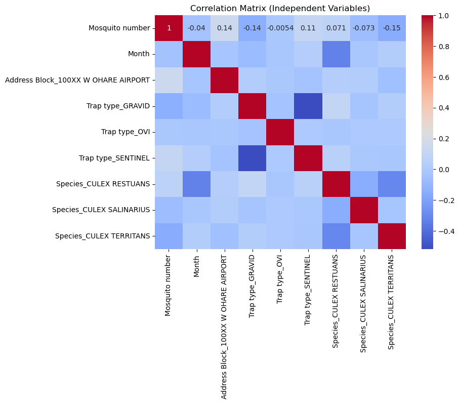

```python
# Heat mapping the correlation matrix of the independent variables.
corr_mat = mosquito_data2_ddf3_X.corr()

# Heatmap for visualization
sns.heatmap(corr_mat, annot=True, cmap='coolwarm')
plt.title('Correlation Matrix (Independent Variables)')
plt.show()
```

```python
# Prepare dependent variable
mosquito_data2_df3b_y = mosquito_data2_df3b['WNV Present']
mosquito_data2_df3b_y.head()

# mosquito_data2_ddf3_2_y = pd.DataFrame(mosquito_data2_ddf3, columns=['WNV Present_negative', 'WNV Present_positive'])
# mosquito_data2_ddf3_2_y.head()
```

```
0    negative
1    negative
2    negative
3    negative
4    negative
Name: WNV Present, dtype: object
```

```python
# Use logit function from statsmodels to fit the logistic regression model

X = mosquito_data2_ddf3_X.replace({True: 1, False: 0})
X_wconst = sm.add_constant(X)

y = mosquito_data2_df3b_y.replace({'positive': 1, 'negative': 0})

# 1. Instantiate model
logreg_wnv_present = sm.Logit(y, X_wconst)

# 2. Fit the model (this returns a separate object with the parameters)
logreg_results = logreg_wnv_present.fit()

logreg_results.summary()
```

```
Warning: Maximum number of iterations has been exceeded.
         Current function value: 0.419578
         Iterations: 35
```

```
C:\Users\raust\anaconda3\Lib\site-packages\statsmodels\base\model.py:607: ConvergenceWarning: Maximum Likelihood optimization failed to converge. Check mle_retvals
  warnings.warn("Maximum Likelihood optimization failed to "
```

### Model Issues

##### 1. I had to replace "True" and "False" entries with "1" and "0" for the model to run. Likewise for "Positive" and "Negative" entries. Otherwise, the program rejected the data with "ValueError: Pandas data to numpy dtype of object. Check input data with np.asarray(data)."

##### 2. There was also a convergence warning: "Maximum Likelihood optimization failed to converge. Check mle_retvals".

##### 3. Finally, there was a related warning stating that the maximum number of iterations had been exceeded. I do not know what to do in these situations. The model still produced an output summary (see below).

```python
# Display the model summary.

logreg_results.summary()
```

Logit Regression Results

| Dep. Variable: | WNV Present | No. Observations: | 18495 |
| --- | --- | --- | --- |
| Model: | Logit | Df Residuals: | 18485 |
| Method: | MLE | Df Model: | 9 |
| Date: | Sun, 09 Nov 2025 | Pseudo R-squ.: | 0.1958 |
| Time: | 16:37:39 | Log-Likelihood: | -7760.1 |
| converged: | False | LL-Null: | -9649.5 |
| Covariance Type: | nonrobust | LLR p-value: | 0.000 |

|  | coef | std err | z | P>\|z\| | [0.025 | 0.975] |
| --- | --- | --- | --- | --- | --- | --- |
| const | -8.0977 | 0.247 | -32.822 | 0.000 | -8.581 | -7.614 |
| Mosquito number | 0.0676 | 0.001 | 47.284 | 0.000 | 0.065 | 0.070 |
| Month | 0.6295 | 0.024 | 26.484 | 0.000 | 0.583 | 0.676 |
| Address Block_100XX W OHARE AIRPORT | 0.5435 | 0.058 | 9.418 | 0.000 | 0.430 | 0.657 |
| Trap type_GRAVID | 0.9670 | 0.129 | 7.523 | 0.000 | 0.715 | 1.219 |
| Trap type_OVI | -13.4217 | 6886.590 | -0.002 | 0.998 | -1.35e+04 | 1.35e+04 |
| Trap type_SENTINEL | 0.7859 | 0.213 | 3.696 | 0.000 | 0.369 | 1.203 |
| Species_CULEX RESTUANS | 0.0673 | 0.046 | 1.456 | 0.145 | -0.023 | 0.158 |
| Species_CULEX SALINARIUS | -0.9581 | 0.318 | -3.011 | 0.003 | -1.582 | -0.334 |
| Species_CULEX TERRITANS | -2.3286 | 0.274 | -8.492 | 0.000 | -2.866 | -1.791 |

```python
# Display the coefficients for review and/or analysis. Calculated coefficients are stored in params
logreg_results.params
```

```
const                                  -8.097730
Mosquito number                         0.067610
Month                                   0.629530
Address Block_100XX W OHARE AIRPORT     0.543477
Trap type_GRAVID                        0.966970
Trap type_OVI                         -13.421723
Trap type_SENTINEL                      0.785912
Species_CULEX RESTUANS                  0.067325
Species_CULEX SALINARIUS               -0.958124
Species_CULEX TERRITANS                -2.328639
dtype: float64
```

```python
# Extracting the coefficients
beta0 = logreg_results.params.iloc[0]
beta1 = logreg_results.params.iloc[1]
beta2 = logreg_results.params.iloc[2]
beta3 = logreg_results.params.iloc[3]
beta4 = logreg_results.params.iloc[4]
beta5 = logreg_results.params.iloc[5]
beta6 = logreg_results.params.iloc[6]
beta7 = logreg_results.params.iloc[7]
beta8 = logreg_results.params.iloc[8]
beta9 = logreg_results.params.iloc[9]
```

```python
# Exponentiate the terms
print("Constant Term:", np.exp(beta0))
print("Mosquito Number:", np.exp(beta1))
print("Month:", np.exp(beta2))
print("Address Block_100XX W OHARE AIRPORT:", np.exp(beta3))
print("Trap type_GRAVID:", np.exp(beta4))
print("Trap type_OVI:", np.exp(beta5))
print("Trap type_SENTINEL:", np.exp(beta6))
print("Species_CULEX RESTUANS:", np.exp(beta7))
print("Species_CULEX SALINARIUS:", np.exp(beta8))
print("Species_CULEX TERRITANS:", np.exp(beta9))
```

```
Constant Term: 0.00030422885940568613
Mosquito Number: 1.0699481589457998
Month: 1.8767285925473223
Address Block_100XX W OHARE AIRPORT: 1.7219831509126733
Trap type_GRAVID: 2.629964639513357
Trap type_OVI: 1.4825850647239271e-06
Trap type_SENTINEL: 2.1944075905222715
Species_CULEX RESTUANS: 1.069643497745642
Species_CULEX SALINARIUS: 0.3836118955645804
Species_CULEX TERRITANS: 0.09742821602400187
```

## Conclusions

##### This model should **NOT** be used for WNV presence prediction.

##### The features correlate poorly with the target variable.

##### More data from relevant features is needed.

##### Data is needed to test the accuracy of the model.